### logistic regression with Artpiece data

```
library(Hmisc)
library(mice)
library(car)
library(caret)
library(ROCR)

Hmisc：實用工具套件
mice：資料模擬使用
car：迴歸應用套件
caret：整合分類與迴歸模型的強大訓練框架
ROCR：ROC曲線可視化工具
```

邏輯迴歸( logistic regression )預測物件屬於兩個類別中的哪一個，這樣的情境在現實生活中滿常見的，以下練習使用的資料集( Artpiece.csv )也是來自 [R Data Mining Blueprints](https://www.packtpub.com/big-data-and-business-intelligence/r-data-mining-blueprints) 書中，主要的目的是預測會不會購買( IsGood.Purchase 欄位)，流程處理上大致相同，不過我加入一些調整及套件的應用，包括 Missing values 處理、交叉驗證及 ROC 曲線等…Artpiece 資料筆數與結構如下:

```
## 'data.frame':    72983 obs. of  8 variables:
##  $ IsGood.Purchase           : int  0 0 0 0 0 0 0 0 0 0 ...
##  $ Critic.Ratings            : num  8.9 9.36 7.38 6.56 6.94 ...
##  $ Acq.Cost                  : num  49700 53200 34300 28700 28000 39200 29400 31500 39200 53900 ...
##  $ CurrentAuctionAveragePrice: int  52157 52192 28245 12908 22729 32963 20860 25991 44919 64169 ...
##  $ Brush.Size                : chr  "1" "1" "2" "1" ...
##  $ CollectorsAverageprice    : int  11433 11808 7802 4776 7034 8536 7707 7355 9836 483 ...
##  $ Is.It.Online.Sale         : int  0 0 0 0 0 0 0 0 0 0 ...
##  $ Min.Guarantee.Cost        : int  7791 7371 9723 4410 7140 4158 3731 5775 3374 11431 ...
```

#### **Missing values imputation**

先利用 Hmisc 套件 describe 方法，查看每個變數的簡易統計及 NA 值情形，其中 CurrentAuctionAveragePrice 欄位有315筆 missing values

```
## Artpiece
##
##  8  Variables      72983  Observations
## ---------------------------------------------------------------------------
## IsGood.Purchase
##        n  missing distinct     Info      Sum     Mean      Gmd
##    72983        0        2    0.324     8976    0.123   0.2157
##
## ---------------------------------------------------------------------------
## Critic.Ratings
##        n  missing distinct     Info     Mean      Gmd      .05      .10
##    72983        0    39947        1     7.15    1.646    4.548    5.055
##      .25      .50      .75      .90      .95
##    6.184    7.336    8.244    8.879    9.252
##
## lowest :  0.4825  0.5368  0.8706  0.9446  0.9878
## highest: 11.2056 11.3617 11.4184 11.5026 11.5717
## ---------------------------------------------------------------------------
## Acq.Cost
##        n  missing distinct     Info     Mean      Gmd      .05      .10
##    72983        0     2072        1    47117    13882    28210    30905
##      .25      .50      .75      .90      .95
##    38045    46900    55300    62860    68425
##
## lowest :      7   1575   9800  11340  12040, highest: 226100 251300 255395 271495 318283
## ---------------------------------------------------------------------------
## CurrentAuctionAveragePrice
##        n  missing distinct     Info     Mean      Gmd      .05      .10
##    72668      315    10315        1    42925    19072    18319    21726
##      .25      .50      .75      .90      .95
##    29925    42434    54152    64157    71720
##
## lowest :      0   2583   3010   3031   4655, highest: 196693 217889 225750 233583 250054
## ---------------------------------------------------------------------------
## Brush.Size
##        n  missing distinct
##    72983        0        5
##
## Value          0     1     2     3  NULL
## Frequency      5 36050 33004   755  3169
```

[output cut: 8 more lines]

```
## lowest :     0     2     3     4     5, highest: 13189 13190 13191 13192 13193
## ---------------------------------------------------------------------------
## Is.It.Online.Sale
##        n  missing distinct     Info      Sum     Mean      Gmd
##    72983        0        2    0.074     1845  0.02528  0.04928
##
## ---------------------------------------------------------------------------
## Min.Guarantee.Cost
##        n  missing distinct     Info     Mean      Gmd      .05      .10
##    72983        0      281        1     8936     4325     3983     4410
##      .25      .50      .75      .90      .95
##     5859     8085    11361    13818    15386
##
## lowest :  3234  3374  3535  3654  3731, highest: 45444 45633 47733 50386 52486
## ---------------------------------------------------------------------------
```

初步了解一下 IsGood.Purchase 資料分佈，類別為 0 (不會購買) 佔了約 87.7 %，類別為 1 的只有 12.3 %。如果 CurrentAuctionAveragePrice 是 NA 而且 IsGood.Purchase 為 1 者，佔其中約 0.3565062 %左右，雖然比例很小、可直接 remove ，不過這裡選擇用 simulate

```r
# 類別資料分佈
prop.table(table(Artpiece$IsGood.Purchase))
```

```
##
##         0         1
## 0.8770125 0.1229875
```

接著，利用 mice 套件方法進行模擬，本次使用 pmm (predictive mean matching)，模擬情形如下

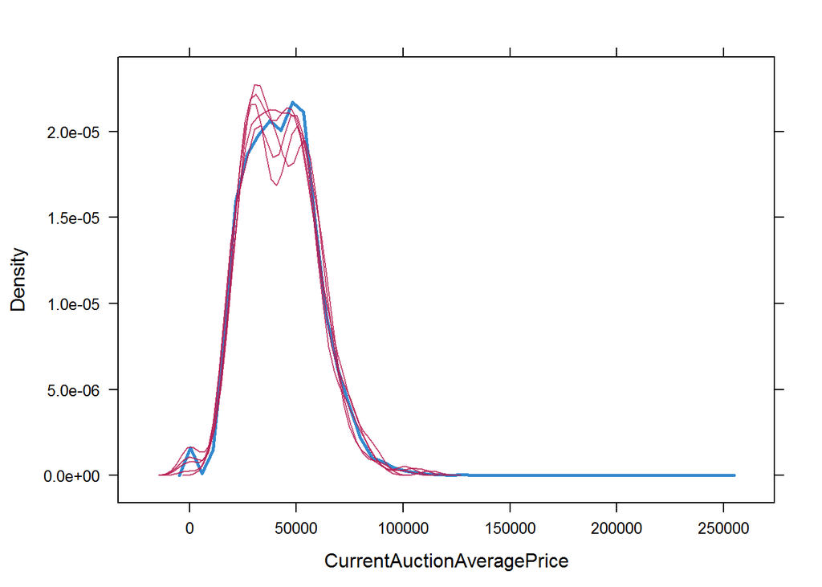

#### **Multicollinearity minimum & Variable selection**

處理完 missing values，接下來針對變數的多重共線性，使用 car 套件的 vif 方法，從結果看來沒有 multicollinearity 問題

```r
model.ini <- glm(IsGood.Purchase ~ ., data = Artpiece.simulate, family = binomial(link = "logit"))
# check multicollinearity
vif(model.ini)
```

```
##                                GVIF Df GVIF^(1/(2*Df))
## Critic.Ratings             1.207771  1        1.098986
## Acq.Cost                   2.578447  1        1.605754
## CurrentAuctionAveragePrice 2.528328  1        1.590072
## Brush.Size                 1.092756  4        1.011150
## CollectorsAverageprice     1.081010  1        1.039716
## Is.It.Online.Sale          1.005236  1        1.002615
## Min.Guarantee.Cost         1.164680  1        1.079203
```

在 variable selection 的部份，這次採用自動方式來篩選，從結果看來保留了所有變數(表示減少變數對 AIC 沒有助益)

```r
# auto detection of model
fit_step <- step(model.ini, direction = "both")
```

```
## Start:  AIC=46688.9
## IsGood.Purchase ~ Critic.Ratings + Acq.Cost + CurrentAuctionAveragePrice +
##     Brush.Size + CollectorsAverageprice + Is.It.Online.Sale +
##     Min.Guarantee.Cost
##
##                              Df Deviance   AIC
## <none>                             46667 46689
## - Is.It.Online.Sale           1    46671 46691
## - Min.Guarantee.Cost          1    46679 46699
## - Acq.Cost                    1    46695 46715
## - CollectorsAverageprice      1    46705 46725
## - CurrentAuctionAveragePrice  1    46822 46842
## - Critic.Ratings              1    46899 46919
## - Brush.Size                  4    52965 52979
```

卡方檢定也能幫助了解需不需要增刪變數，查看一下 independent variables 依續加入 model 是否有助於殘差的減少，從這結果看來變數不需刪減

```r
# chi-square test statistics
anova(fit_step, test = "Chisq")
```

```
## Analysis of Deviance Table
##
## Model: binomial, link: logit
##
## Response: IsGood.Purchase
##
## Terms added sequentially (first to last)
##
##
##                            Df Deviance Resid. Df Resid. Dev  Pr(>Chi)
## NULL                                       72982      54421
## Critic.Ratings              1    514.7     72981      53907 < 2.2e-16 ***
## Acq.Cost                    1    655.9     72980      53251 < 2.2e-16 ***
## CurrentAuctionAveragePrice  1    217.0     72979      53034 < 2.2e-16 ***
## Brush.Size                  4   6311.0     72975      46723 < 2.2e-16 ***
## CollectorsAverageprice      1     39.8     72974      46683 2.815e-10 ***
## Is.It.Online.Sale           1      4.4     72973      46679 0.0369004 *
## Min.Guarantee.Cost          1     11.7     72972      46667 0.0006292 ***
## ---
## Signif. codes:  0 '***' 0.001 '**' 0.01 '*' 0.05 '.' 0.1 ' ' 1
```

初步 model 預測值分佈情形如下

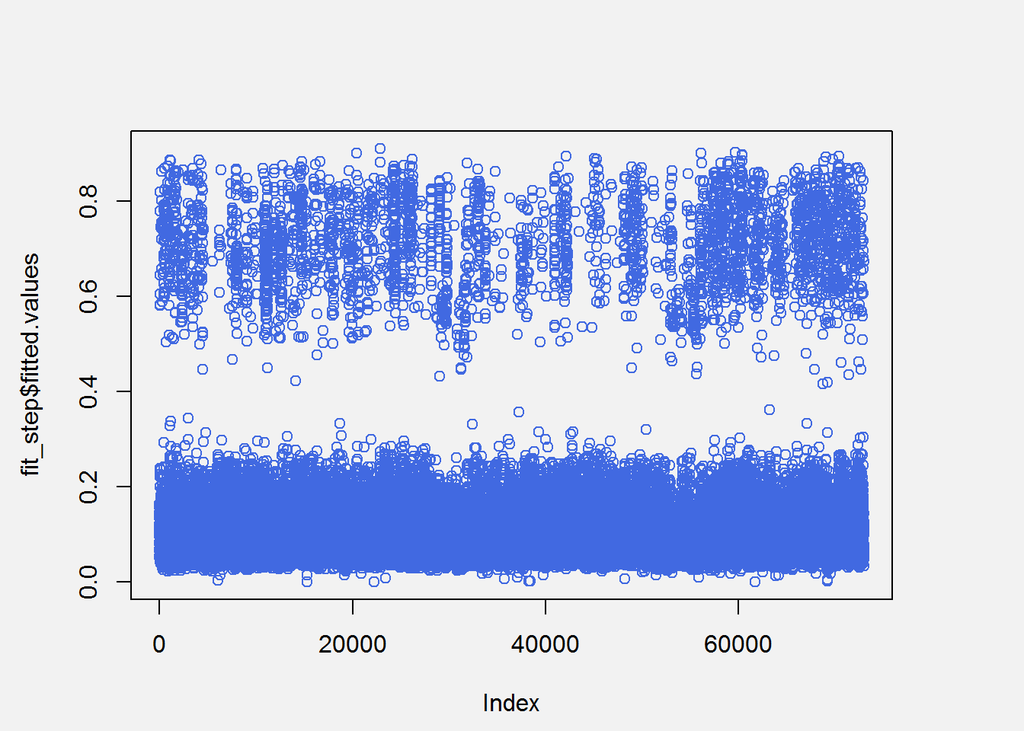

#### **Cross-validation**

資料和變數 ready 好了，接下來使用 glm 的邏輯迴歸，採用 10 fold CV 進行 accuracy 檢測

```r
# glm cv
set.seed(777)
folds <- createFolds(Artpiece.simulate$IsGood.Purchase, k = 10)
cv_results <- lapply(folds, function(x) {
  train_data <- Artpiece.simulate[-x, ]
  test_data <- Artpiece.simulate[x, ]
  glm.fit <- glm(IsGood.Purchase ~ ., data = train_data, family = binomial(link = "logit"))
  pred_data <- ifelse(predict(glm.fit, newdata = test_data, type = 'response') > 0.5, 'Y', 'N')
  actual_data <- test_data$IsGood.Purchase
  acc_tb <-  table(actual_data, pred_data)
  acc <- (acc_tb[1, 1] + acc_tb[2, 2]) / sum(acc_tb)
  return(acc)
})
```

結果如下，平均 accuracy 為 0.8947563

```
## List of 10
##  $ Fold01: num 0.896
##  $ Fold02: num 0.893
##  $ Fold03: num 0.893
##  $ Fold04: num 0.893
##  $ Fold05: num 0.898
##  $ Fold06: num 0.893
##  $ Fold07: num 0.894
##  $ Fold08: num 0.894
##  $ Fold09: num 0.895
##  $ Fold10: num 0.898
```

caret 套件也有支援 glm，執行結果相同

```r
# caret glm cv
set.seed(777)
model.glm <- train(IsGood.Purchase ~ ., data = Artpiece.simulate, metric = "Accuracy",
                   family = binomial, trControl = ctrl, method = "glm")
getBest(model.glm)
```

| parameter | Accuracy | Kappa | AccuracySD | KappaSD |
| --- | --- | --- | --- | --- |
| none | 0.8947563 | 0.3221718 | 0.0022876 | 0.0151984 |

#### **ROC curve**

model 建立後的預測機率可用來產出 ROC curve，它被用來權衡 true positives (TP) 和 false positives (FP) 間的檢測、了解機器學習 model 的功效，由於 ROCR 套件支援參數及可視化我比較習慣，因此採用這個套件來處理，其他如 pROC 套件也有類似功能。 從下圖看來，如果要正確識別都達到機率 0.7 的話要面臨 0.4 左右的誤判

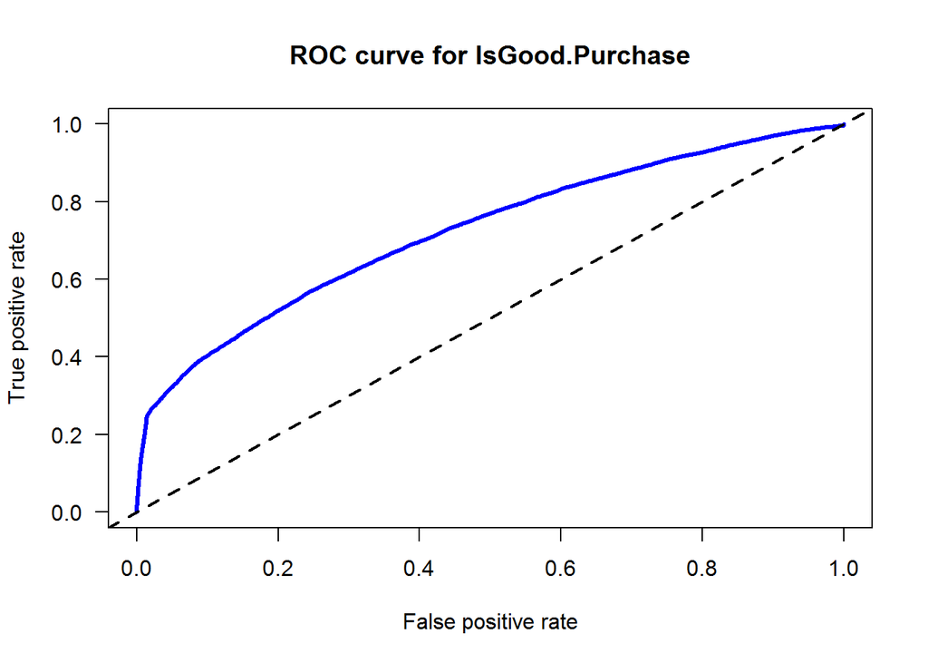

```r
# ROC
pred <- prediction(predictions = model.glm$finalModel$fitted.values,
                   labels = Artpiece.simulate$IsGood.Purchase)
perf <- performance(pred, "tpr", "fpr")
plot(perf, col = "blue", lwd = 3, yaxis.las = 1, yaxis.at = seq(0, 1, by = 0.2),
     main = "ROC curve for IsGood.Purchase")
abline(a = 0, b = 1, lwd = 2, lty = 2)
```

AUC (area under the ROC curve) 是計算 ROC curve 以下的面積。兩條 ROC curves 可能有相同的 AUC，為避免對 AUC 值的誤解，通常搭配 ROC 一起解讀。AUC 值參考意義如下，從本次執行結果來看，只能算是普通

| Grades | AUC Scores |
| --- | --- |
| Outstanding | 0.9 ~ 1.0 |
| Excellent | 0.8 ~ 0.9 |
| Acceptable | 0.7 ~ 0.8 |
| Poor | 0.6 ~ 0.7 |
| No discrimination | 0.5 ~ 0.6 |

```r
#計算AUC面積
perf.auc <- performance(pred, "auc")
perf.auc@y.values[[1]]
```

```
## [1] 0.722991
```

### Lessons Learned:

#### ROC curve / area under the ROC curve (AUC)